# CLUSTER ANALYSIS:

Hierarchical Clustering, K-Means Clustering, DBSCAN, and Mixture Models

Marco R. Steenbergen

University of Zurich

# Overview

## What Is Cluster Analysis?

- An approach that groups instances on the basis of a set of features.
  - Cf. principal component analysis, which concerns grouping features.
- This is part of unsupervised machine learning.
- It has found widespread use in political science.

[figure not shown]

## Varieties of Cluster Analysis

```
flowchart LR
A[Hierarchical?]-->|Yes|B[Hierarchical\nClustering]
A-->|No|C[Need to\nspecify k?]
C-->|No|D[DBSCAN]
C-->|Yes|E[Categorical\nFeatures?]
E-->|Yes|F[k-Modes]
E-->|No|G[Probabilistic\nModel?]
G-->|Yes|H[Gaussian\nMixture]
G-->|No|I[k-Means]
```

# Data

## Political Party Positions in the Netherlands

[interactive chart not shown]

## The Research Question

> Can we find clusters of political parties based on three dimensions of political conflict:
> 1. Economic left-right.
> 2. GAL-TAN.
> 3. EU position.

# Hierarchical Clustering

## What Is Hierarchical Clustering?

- Builds a hierarchy of clusters (Johnson, 1967).
- This can be done in two ways:
  1. Agglomarative—start with single units and fuse them into clusters.
  2. Divisive—start with one cluster and divide it.
- Clustering decisions cannot be revoked.

## The Workflow

1. Measure $n$ instances on $p$ features.
2. Generate a $n \times n$ distance matrix.
3. Form clusters.
4. Decide on the number of clusters.
5. Interpret through cluster profiles.

## Distance Matrix

- Recap
- Syntax
- Results
- We discussed this when we covered KNN.
- Typically, Euclidean distances are employed but many alternatives exist.
- If a Minkowski metric like Euclidean distance is used, make sure the features are on comparable scales.

```r
X <- nl_df[,2:4]
row.names(X) <- nl_df[,1]
dist_mat <- dist(X, method = "minkowski", p = 2)
```

```
             CDA      PvdA       VVD       D66        GL       SGP        SP
PvdA    5.132046
VVD     2.610862  4.991282
D66     6.002716  3.271406  4.491815
GL      7.716411  2.608084  7.240152  3.913438
SGP     3.702891  8.269710  5.461904  9.477088 10.850834
SP      6.520100  4.009813  7.167391  6.988240  5.113560  8.062524
CU      2.904014  5.465108  5.082765  7.618773  7.941442  3.532549  4.969849
PVV     4.027369  6.822038  4.694880  8.108483  9.158237  3.214390  6.053363
PvdD    6.119567  3.313246  5.914465  5.476541  4.417839  8.062165  2.282148
50PLUS  3.095319  3.359003  3.941878  5.508212  5.797189  5.190800  3.485671
DENK    3.282027  4.643038  5.319126  7.112264  7.024849  4.706198  4.286910
FvD     5.016672  8.988865  5.287135  9.514757 11.392313  3.092216  8.860751
              CU       PVV      PvdD    50PLUS      DENK
PvdA
VVD
D66
GL
SGP
SP
CU
PVV     3.564407
PvdD    5.520815  5.577042
50PLUS  2.557675  3.633112  3.206821
DENK    1.210372  4.489276  5.065590  2.315405
FvD     5.595686  2.850842  8.155471  6.051297  6.680786
```

## Agglomarative Algorithms

1. Single linkage/nearest neighbor.
2. Complete linkage/furthest neighbor.
3. Average linkage.
4. Ward’s ESS.

## Single Linkage

- Algorithm
- Iteration 1
- Iteration 2
- Iteration 3
- Dendrogram
1. Find those two objects that are closest and form $C_1$.
2. Decide, based on *minimum* distance, whether
   - to join in another object OR
   - build $C_2$ from two previously unclustered instances
3. Continue until all objects have been clustered.

```
     CDA  VVD  D66   GL
VVD 2.61
D66 6.00 4.49
GL  7.72 7.24 3.91
PVV 4.03 4.69 8.11 9.16
```

The smallest distance is between CDA and VVD $\Rightarrow C_1$.

- $d_{C_1,D66} = \min \left[ d_{CDA,D66}, d_{VVD,D66} \right] = 4.49$.
- $d_{C_1,GL} = \min \left[ d_{CDA,GL}, d_{VVD,GL} \right] = 7.24$.
- $d_{C_1,PVV} = \min \left[ d_{CDA,PVV}, d_{VVD,PVV} \right] = 4.03$.

|  | C1 | D66 | GL | PVV |
| --- | --- | --- | --- | --- |
| **C1** | – |  |  |  |
| **D66** | 4.49 | – |  |  |
| **GL** | 7.24 | 3.91 | – |  |
| **PVV** | 4.03 | 8.11 | 9.16 | – |

The smallest distance is between D66 and GL $\Rightarrow C_2$.

- $d_{C_1,PVV} = \min \left[ d_{CDA,PVV}, d_{VVD,PVV} \right] = 4.03$.
- $d_{C_2,PVV} = \min \left[ d_{D66,PVV}, d_{GL,PVV} \right] = 8.11$.

|  | C1 | C2 | PVV |
| --- | --- | --- | --- |
| **C1** | – |  |  |
| **C2** | 4.49 | – |  |
| **PVV** | 4.03 | 8.11 | – |

The smallest distance is between $C_1$ and PVV $\Rightarrow$ join in PVV.

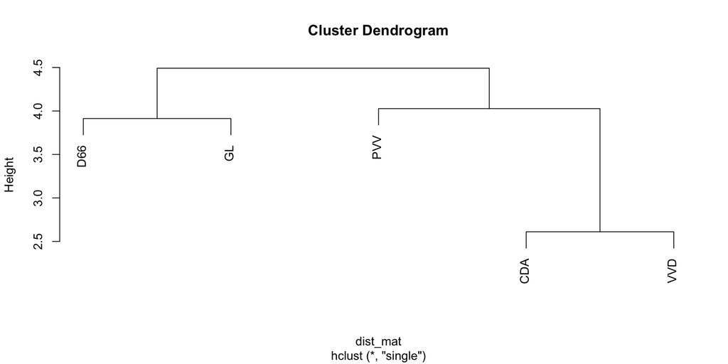

## Complete Linkage

- Algorithm
- Dendrogram
1. Find those two objects that are closest and form $C_1$.
2. Decide, based on *maximum* distance, whether
   - to join in another object OR
   - build $C_2$ from two previously unclustered instances
3. Continue until all objects have been clustered.

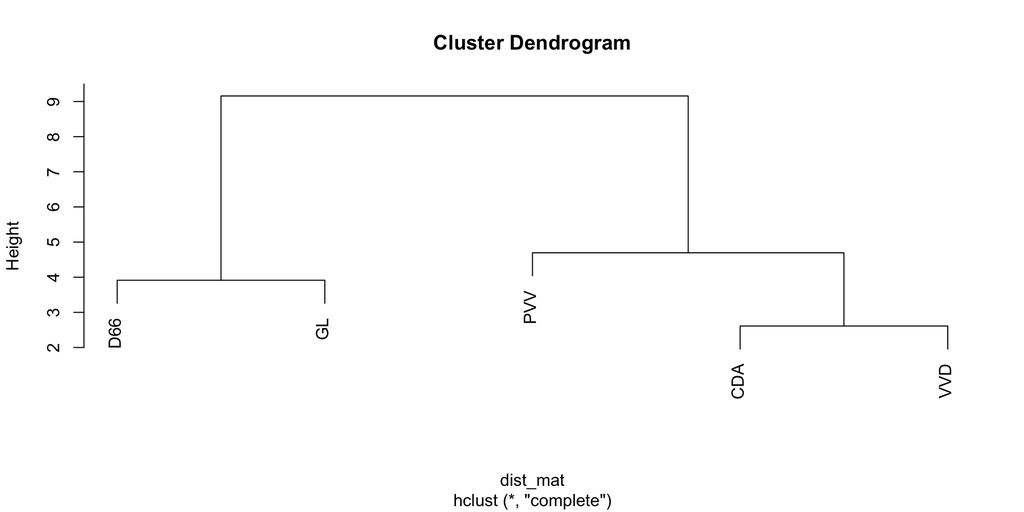

## Average Linkage

- Algorithm
- Dendrogram
- Cluster distances are the average between the instances contained in $C_i$ and $C_j$.
- A compromise between single and complete linkage

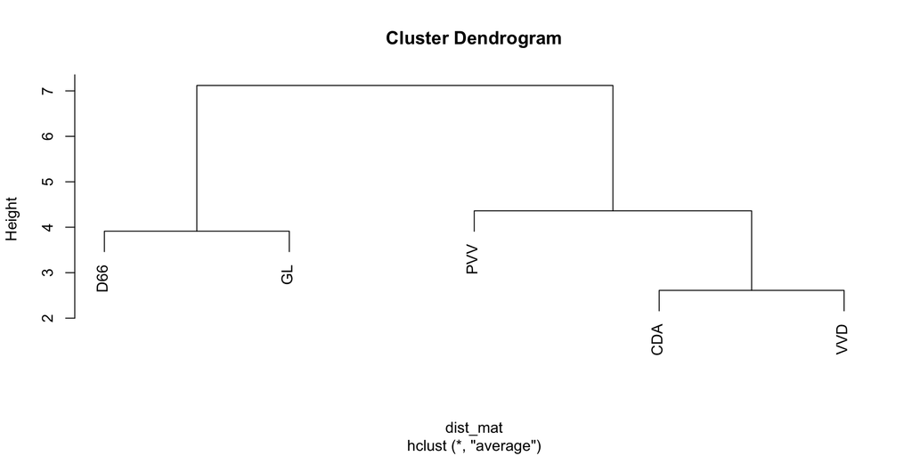

## Ward’s Error Sum of Squares

- Algorithm
- GAL-TAN
- Iteration 1
- Iteration 2
- Iteration 3
- Based on the loss of information when we group instances and treat them as a single entity (Ward, 1963).
- For one feature, the loss of information given $k$ clusters and $n_j$ instances per cluster is

  $$ESS = \sum_{j=1}^k \left \{ \sum_{i=1}^{n_j} (x_{ij} - \bar{x}_j)^2 \right \}$$
- We minimize the error sum of squares, i.e., the squared deviation of instance’s values from their cluster means.

| CDA | D66 | GL | PVV | VVD |
| --- | --- | --- | --- | --- |
| 7.15 | 1.38 | 0.85 | 7.23 | 5.00 |

| Cluster | Mean | ESS | Cluster | Mean | ESS |
| --- | --- | --- | --- | --- | --- |
| CDA-D66 | 4.27 | 16.65 | D66-PVV | 4.31 | 17.11 |
| CDA-GL | 4.00 | 19.85 | D66-VVD | 3.19 | 6.55 |
| **CDA-PVV** | 7.19 | 0.00 | GL-PVV | 4.04 | 20.35 |
| CDA-VVD | 6.08 | 2.31 | GL-VVD | 2.93 | 8.61 |
| D66-GL | 1.12 | 0.14 | PVV-VVD | 6.12 | 2.49 |

The smallest ESS is for a cluster between CDA and PVV.

| Cluster | Mean | ESS |
| --- | --- | --- |
| CDA/PVV-D66 | 5.25 | 22.51 |
| CDA/PVV-GL | 5.08 | 26.80 |
| CDA/PVV-VVD | 6.46 | 3.20 |
| **D66-GL** | 1.12 | 0.14 |
| D66-VVD | 3.19 | 6.55 |
| GL-VVD | 2.93 | 8.61 |

| Cluster | Mean | ESS |
| --- | --- | --- |
| **CDA/PVV-VVD** | 6.46 | 3.20 |
| D66/GL-VVD | 2.41 | 10.20 |

The smallest ESS arises when we fuse VVD with the CDA-PVV cluster.

## Which Agglomorative Method?

- Single linkage is more sensitive to nuance.
- Complete linkage is more robust against noise.
- Average linkage is a compromise.
- In practice, we often decide based on the **agglomarative coefficient** (Kaufman & Rousseeuw, 1990):
  - $a \in [0,1]$
  - Higher values indicate a greater ease of clustering

## Clustering the Dutch Data 1

- `hclust`
- Syntax
- Ward
- Single
- Complete
- Average
- `hclust` is built into the `stats` package and part of the standard installation of R.
- It has basic functionality but misses some of the options found in other packages.

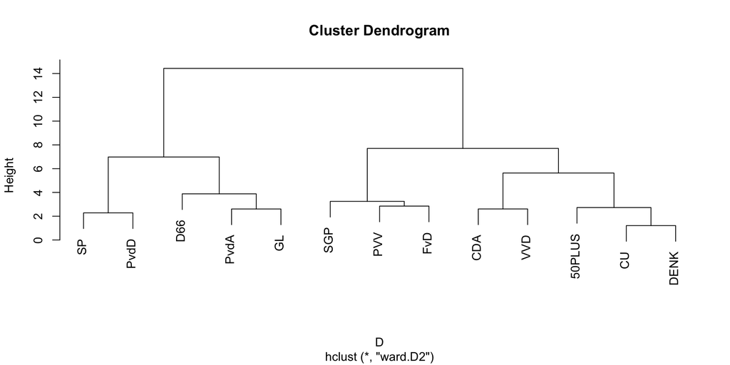

```r
X <- nl_df[,2:4]
row.names(X) <- nl_df[,1]
D <- dist(X, method = "minkowski", p = 2)
fit <- hclust(D, method = "name")
# name is one of ward.D2, single, complete, average (or others)
plot(fit)
```

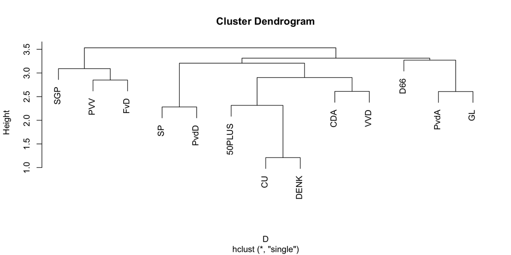

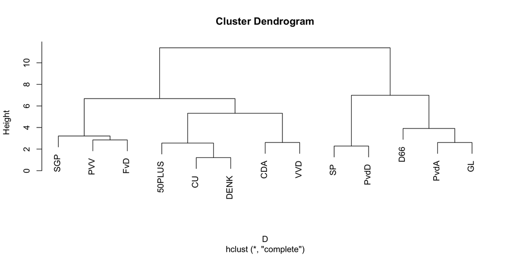

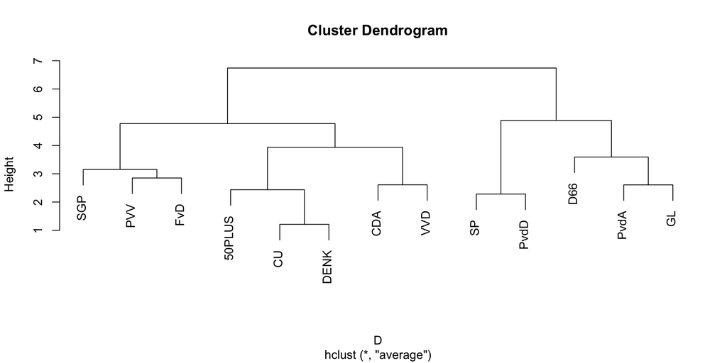

## Clustering the Dutch Data 2

- `agnes`
- $a$
- A function for aglomarative clustering in the package `cluster`.
- Has more functionality than `hclust`.

```r
library(cluster)
m <- c("average", "single", "complete", "ward")
names(m) <- c("average", "single", "complete", "ward")
X <- nl_df[, 2:4]
ac <- function(x) {
  agnes(X, method = x)$ac
}
map_dbl(m, ac)
```

```
  average    single  complete      ward
0.6313596 0.3074592 0.7784598 0.8242083
```

Ward’s algorithm performs the best in terms of the agglomarative coefficient.

## Divisive Algorithms

- Idea
- Step 1
- Step 2
- Step 3

A common divisive algorithm is the splinter-average distance method:

1. Start with one cluster encompassing all instances.
2. Splinter out the instance with the largest distance to the remaining instances $\Rightarrow$ 2 clusters.
3. Compute distances to the main cluster and the splinter and decide on further splits.
4. Continue until stabilization is reached.

The distance matrix is
$$\boldsymbol{D} = \left[ \begin{array}{rrrrrr} & CDA & VVD & D66 & GL & PVV \\ CDA & 0.00 & 2.61 & 6.00 & 7.72 & 4.03 \\ VVD & 2.61 & 0.00 & 4.49 & 7.24 & 4.69 \\ D66 & 6.00 & 4.49 & 0.00 & 3.91 & 8.11 \\ GL &7.72 & 7.24 & 3.91 & 0.00 & 9.16 \\ PVV & 4.03 & 4.69 & 8.11 & 9.16 & 0.00 \end{array} \right]$$

The average distances are 5.09 for CDA, 4.76 for VVD, 5.63 for D66, 7.01 for GL, and 6.50 for PVV $\Rightarrow$ splinter out GL.

| Party | Avg. Distance to Splinter | Avg. Distance to Main | Difference |
| --- | --- | --- | --- |
| CDA | 7.72 | 4.21 | 3.51 |
| VVD | 7.24 | 3.93 | 3.31 |
| D66 | 3.91 | 6.20 | -2.29 |
| PVV | 9.16 | 5.61 | 3.55 |

D66 is, on the average, closer to GL than to the other parties $\Rightarrow$ we splinter out D66 and fuse it with GL.

| Party | Avg. Distance to Splinter | Avg. Distance to Main | Difference |
| --- | --- | --- | --- |
| CDA | 6.86 | 3.32 | 3.54 |
| VVD | 5.87 | 3.65 | 2.22 |
| PVV | 8.64 | 4.36 | 4.28 |

The three parties are, on the average, closer to their cluster partners than to the splinter $\Rightarrow$ the solution is stabilized with $C_1 = \{CDA, PVV, VVD\}$ and $C_2 = \{D66, GL\}$.

## Divisive Clustering of the Dutch Party Data

- Syntax
- Coefficient
- Plot

```r
row.names(X) <- nl_df$party
divisive_fit <- diana(X)
divisive_fit$dc
pltree(divisive_fit, cex = 0.6, hang = -1, main = "Divisive Clustering")
```

```
[1] 0.7784598
```

This is the divisive coefficient, $a$’s equivalent in divisive clustering.

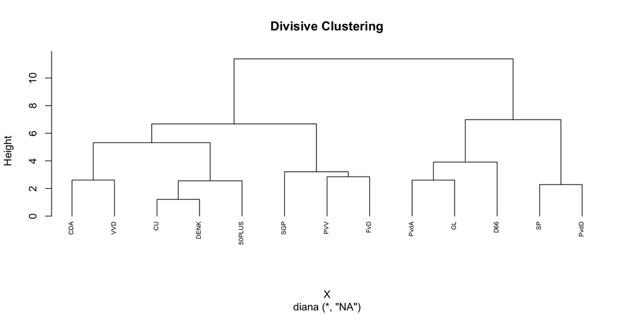

## Choosing the Number of Clusters

1. Elbow method.
2. Silhouette method.
3. Gap statistic.

## Elbow Method

- Method
- Syntax
- Result
1. Compute the algorithm for different cluster sizes, $k$.
2. For each choice of $k$, compute the within-cluster sum of squares (WSS) as a measure of cluster heterogeneity.
3. Plot WSS against $k$.
4. The location of the bend (elbow) is the optimal $k$.

```r
library(factoextra)
library(NbClust)
fviz_nbclust(X, hcut, method = "wss", k.max = 10)
```

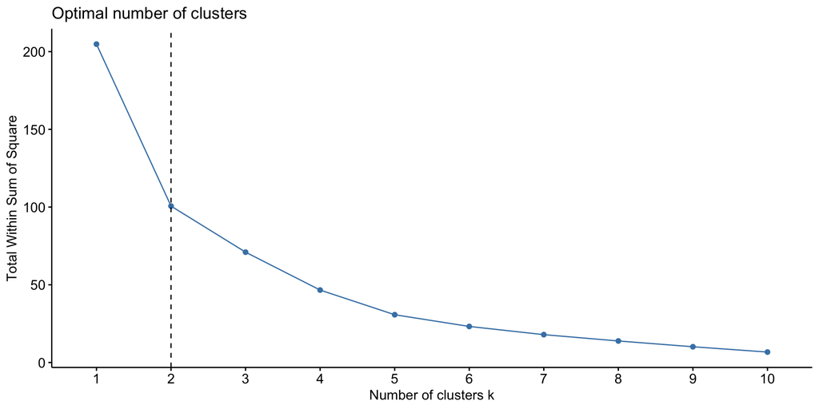

## Silhouettes

- Silhouette
- Interpretation
- Workflow
- Syntax
- Results
- The silhouette coefficient measures the average distance between clusters (Kaufman & Rousseeuw, 1990).
- It is computed as follows:
  - For instance $i$, compute the average dissimilarity, $a_i$, to the other instances in the cluster to which $i$ belongs.
  - For all other clusters to which $i$ does not belong, assess the average dissimilarity, $d_i$.
  - Compute $i$’s distance to the nearest other cluster: $b_i = \min d_i$.
  - Compute

    $$S_i = \frac{b_i - a_i}{\max (a_i,b_i)}$$
- If $S_i \rightarrow 1$ then the instance is clustered well.
- If $S_i \rightarrow 0$ then the instance lies between clusters.
- If $S_i < 0$ then the instance is in the wrong cluster.
1. Compute the algorithm for different cluster sizes, $k$.
2. For each choice of $k$, compute the average silhouette coefficient, $\bar{S}$.
3. Plot $\bar{S}$ against $k$.
4. The location of the maximum is the optimal $k$.

```r
library(factoextra)
library(NbClust)
fviz_nbclust(X, hcut, method = "silhouette", k.max = 10)
```

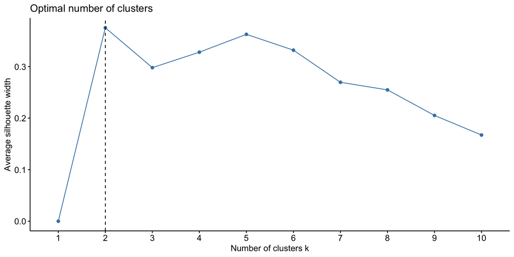

## Gap Statistic

- Statistic
- Workflow
- Syntax
- Results
- Compares total within-cluster variation, $W$, to a null reference distribution, i.e., a random uniform distribution (Tibshirani et al., 2001).
- The optimal $k$ maximizes the gap with the reference distribution.
1. Compute the algorithm for different cluster sizes, $k$.
2. For each choice of $k$, compute $W_k$.
3. Generate $B$ reference data sets with random uniform distributions. A common value is $B = 500$.
4. Cluster each distributions for different choices of $k$ and compute $W_{kb}$.
5. Compute the gap as $G(k) = \frac{1}{B} \sum_{b=1}^B \ln (W_{kb}) - \ln (W_k)$.
6. Select $k$ as the smallest value such that $G$ is within one standard deviation of the gap at $k+1$, i.e., $G(k) \geq G(k+1) - \text{SE}[G(k+1)]$.

```r
library(factoextra)
library(NbClust)
fviz_nbclust(X, hcut, method = "gap_stat", k.max = 10, nboot = 500,
             verbose = FALSE)
```

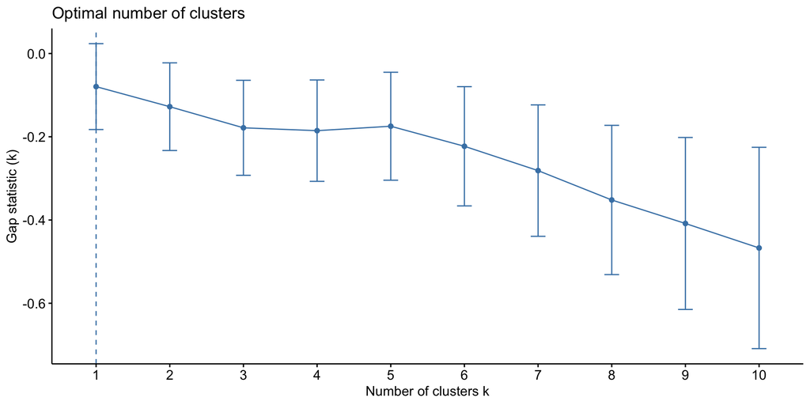

## Plotting Dendrograms

- Syntax
- Plot

```r
# Order of labels in terminal as in dendrogram
library(dendextend)
ward_fit <- dutch_df[,2:4] %>%
  dist(method = "euclidean") %>%
  hclust(method = "ward.D2") %>%
  as.dendrogram()
terminal <- c("SP", "PvdD", "D66", "PvdA", "GL", "SGP", "PVV",
              "FvD", "CDA", "VVD", "50PLUS", "CU", "DENK")
labels(ward_fit) <- terminal
ward_fit %>%
  set("labels_col", value = c("blue", "red"), k = 2) %>%
  set("branches_lwd", 2) %>%
  plot
```

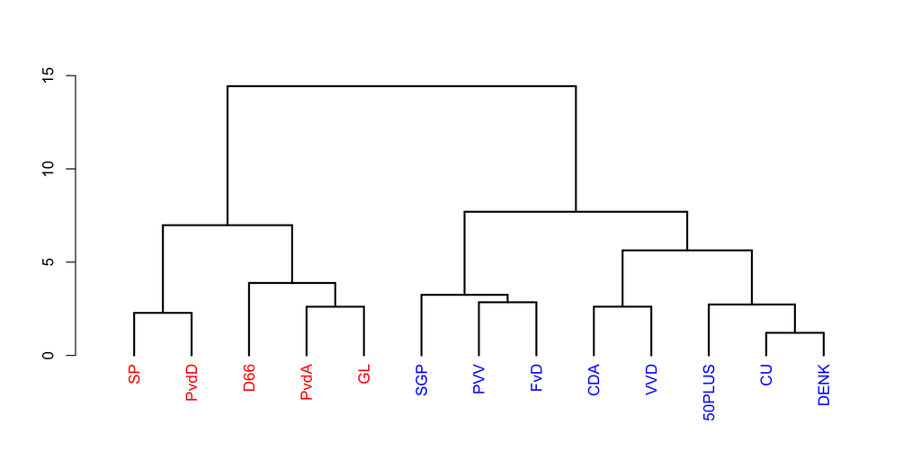

## Interpretation

- Allocations
- Centroids

```r
nl_df <- nl_df %>%
  mutate(cluster = ifelse(party=="SP"|party=="PvdD"|party=="D66"|
                            party=="PvdA"|party=="GL", 1, 2),
         cluster = factor(cluster, labels = c("C1", "C2")))
table(nl_df$cluster)
```

```
C1 C2
 5  8
```

```r
nl_df %>%
  group_by(cluster) %>%
  summarise(EU = mean(eu), LRECON = mean(lrecon), GALTAN = mean(galtan))
```

```
# A tibble: 2 × 4
  cluster    EU LRECON GALTAN
  <fct>   <dbl>  <dbl>  <dbl>
1 C1       4.95   3.36   2.51
2 C2       3.53   6.23   7.37
```

- Cluster 1 tends to be Europhile compared to cluster 2.
- Cluster 1 is economically left; cluster 2 is economically right.
- Cluster 1 is GAL; cluster 2 is TAN.

# $k$-Means Clustering

## Rendering Cluster Assignments Revocable

- In hierarchical clustering, allocations are irrevocable:
  - Once unit $i$ has been placed in cluster $C$, it will stay there forever.
- We relax this in $k$-means clustering.
- *Note:* $k$-means clustering is for continuous features; for nominal features, there is $k$-mode clustering, which we will not cover here.

## Workflow

1. Choose the number of clusters, $k$.
2. Perform an initial cluster allocation.
3. Update the allocation with the goal of generating purer (i.e., more homogeneous) clusters.
4. Repeat the process for different choices of $k$ and ascertain the optimum number of clusters.

## Major Algorithms

1. Hartigan-Wong (Hartigan & Wong, 1979).
2. Lloyd-Forgy (Forgy, 1965; Lloyd, 1982).
3. MacQueen (MacQueen, 1967).

Of these, we shall discuss Hartigan-Wong and Lloyd-Forgy, since they are used most frequently. All three methods are available through R’s `kmeans` function.

## Logic

- Notation
- Distortion
- Principle
- Consider instances $i = 1, \cdots, n$.
- Each instance is characterized by a vector $\boldsymbol{x}_i$ of numeric features.
- The clusters form a set ${\cal C} = \{ C_1, \cdots, C_k \}$.
- Cluster $C_j$ has $n_j$ members.
- Its centroid is $\bar{\boldsymbol{x}}_j = \sum_{i \in C_j} \boldsymbol{x}_i/n_j$.
- Define a distance metric, $d$, e.g., Euclidean.
- For cluster $C_j$ define $\sum_{i \in C_j} d(\boldsymbol{x}_i,\bar{\boldsymbol{x}}_j)$.
- Sum over all clusters and divide by $n$:

  $$D({\cal C}) = \frac{1}{n} \sum_j \sum_{i \in C_j} d(\boldsymbol{x}_i,\bar{\boldsymbol{x}}_j)$$
- Relocate instances to reduce $D({\cal C})$.
- This is done in a greedy manner, i.e., local rather than global optimization.

## Lloyd-Forgy Initial Allocation

- Approach
- Example

Randomly assign instances to $k$ clusters.

[output not shown]

## Lloyd-Forgy Updates

- Step 1
- Step 2
- Step 3

| Cluster | Mean EU | Mean Economy | Mean GAL-TAN |
| --- | --- | --- | --- |
| 1 | 4.37 | 5.18 | 5.08 |
| 2 | 6.00 | 7.19 | 3.19 |

| Party | Distance to C1 | Distance to C2 | Allocation |
| --- | --- | --- | --- |
| CDA | 7.52 | 16.38 | 1 |
| D66 | 21.29 | 5.04 | 2 |
| GL | 30.07 | 28.82 | **2** |
| PVV | 15.63 | 38.85 | 1 |
| VVD | 9.36 | 5.04 | 2 |

GL is moved into cluster 2.

| Cluster | Mean EU | Mean Economy | Mean GAL-TAN |
| --- | --- | --- | --- |
| 1 | 3.32 | 6.58 | 7.19 |
| 2 | 6.15 | 5.59 | 2.41 |

| Party | Distance to C1 | Distance to C2 | Allocation |
| --- | --- | --- | --- |
| CDA | 4.05 | 24.36 | 1 |
| D66 | 46.84 | 2.06 | 2 |
| GL | 67.65 | 12.81 | 2 |
| PVV | 4.05 | 47.45 | 1 |
| VVD | 10.37 | 14.43 | **1** |

VVD is moved to cluster 1

| Cluster | Mean EU | Mean Economy | Mean GAL-TAN |
| --- | --- | --- | --- |
| 1 | 3.91 | 7.10 | 6.46 |
| 2 | 6.69 | 4.31 | 1.12 |

| Party | Distance to C1 | Distance to C2 | Allocation |
| --- | --- | --- | --- |
| CDA | 2.67 | 43.96 | 1 |
| D66 | 35.64 | 3.83 | 2 |
| GL | 60.27 | 3.83 | 2 |
| PVV | 7.75 | 70.98 | 1 |
| VVD | 4.61 | 32.47 | 1 |

Stabilized.

## Hartigan-Wong Initial Allocation

- Approach
- Example

Given a set of $P$ normalized/standardized features,

1. Generate $S_i = \sum_{j=1}^P x_{ij}$ as the total score for an instance.
2. Compute $R = \max (S_i) - \min (S_i)$ as the range.
3. Compute the cluster allocation as

   $$c = \text{Int} \left( \frac{k}{R} [S_i - \min (S_i)] +1 \right)$$

| Party | EU | Economy | GAL-TAN | Score | Normalized Score | Cluster |
| --- | --- | --- | --- | --- | --- | --- |
| CDA | 5.33 | 6.69 | 7.15 | 19.17 | 1.00 | 2 |
| D66 | 6.92 | 6.23 | 1.38 | 14.53 | 0.51 | 2 |
| GL | 6.46 | 2.38 | 0.85 | 9.69 | 0.00 | 1 |
| PVV | 1.31 | 6.46 | 7.23 | 15.00 | 0.56 | 2 |
| VVD | 5.08 | 8.15 | 5.00 | 18.23 | 0.90 | 2 |

## Hartigan-Wong Updates

- Principle
- Step 1
- Step 2
- Similar idea to Lloyd, but unit $i$ is not considered when computing cluster centroids.
- The algorithm thus functions as follows:
  1. Remove a single unit $i$ from $C_j$ and turn it into a singleton.
  2. Update the centroids.
  3. Re-assign the unit to the cluster with the closest centroid.

| Party | Cluster | EU Centroid | Econ Centroid | GAL-TAN Centroid | Dist to C1 | Dist to C2 | New |
| --- | --- | --- | --- | --- | --- | --- | --- |
| CDA | 2 | 4.44 | 6.95 | 4.54 | 26.28 | 7.69 | 2 |
| D66 | 2 | 3.91 | 7.10 | 6.46 | 15.32 | 35.64 | **1** |
| PVV | 2 | 5.78 | 7.02 | 4.51 | 83.87 | 27.67 | 2 |
| VVD | 2 | 4.52 | 6.46 | 5.25 | 52.42 | 3.23 | 2 |
| GL | 1 | – | – | – | 0.00 | 42.35 | 1 |

Centroids computed after dropping a party from its cluster.

| Party | Cluster | EU Centroid | Econ Centroid | GAL-TAN Centroid | Dist to C1 | Dist to C2 | New |
| --- | --- | --- | --- | --- | --- | --- | --- |
| CDA | 2 | 3.20 | 7.31 | 6.12 | 43.96 | 6.01 | 2 |
| PVV | 2 | 5.21 | 7.42 | 6.08 | 70.98 | 17.43 | 2 |
| VVD | 2 | 3.32 | 6.58 | 7.19 | 32.47 | 10.37 | 2 |
| D66 | 1 | 6.46 | 2.38 | 0.85 | 15.32 | 35.64 | 1 |
| GL | 1 | 6.92 | 6.23 | 1.38 | 15.32 | 60.27 | 1 |

Stabilized.

## Which Method?

- Local optimums are a problem with $k$-means clustering.
- Slonim et al. (2013) suggest that Hartigan-Wong is less prone to the problem than other algorithms.

## Choosing the Number of Clusters

- Elbow
- Silhouette
- Gap Statistic

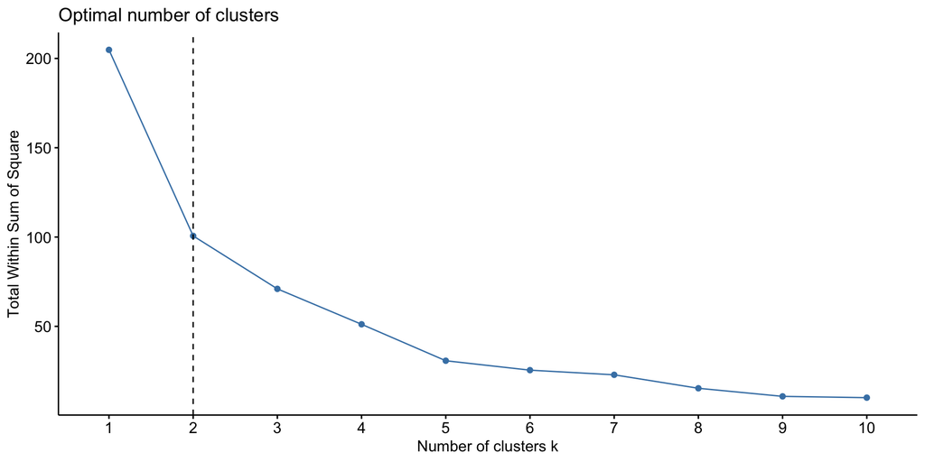

```r
fviz_nbclust(X, kmeans, method = "wss", k.max = 10) +
  geom_vline(xintercept = 2, linetype = 2)
```

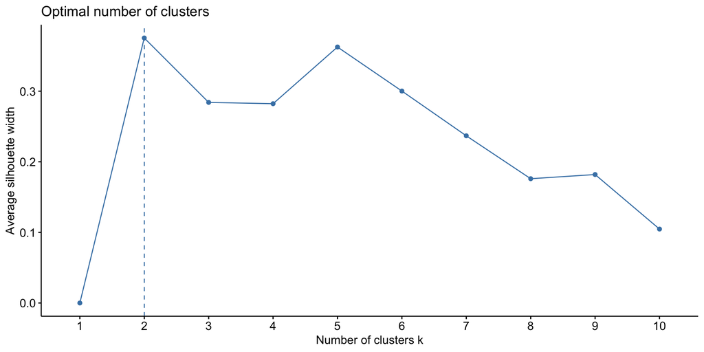

```r
fviz_nbclust(X, kmeans, method = "silhouette", k.max = 10)
```

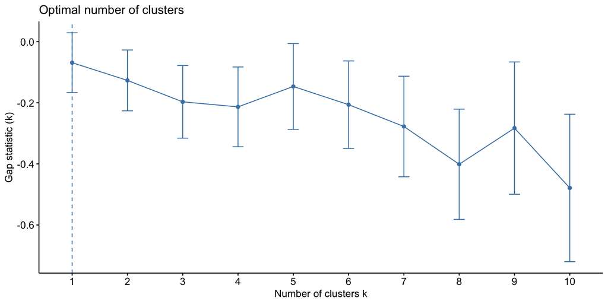

```r
fviz_nbclust(X, kmeans, method = "gap_stat", k.max = 10, nboot = 500,
             verbose = FALSE)
```

## $k$-Means Clustering of Dutch Parties

- Syntax
- Allocations
- Centroids

```r
X <- nl_df[,2:4]
row.names(X) <- nl_df$party
km_fit <- kmeans(X, 2, algorithm = "Hartigan-Wong")
```

```r
km_fit$cluster
```

```
   CDA   PvdA    VVD    D66     GL    SGP     SP     CU    PVV   PvdD 50PLUS
     2      1      2      1      1      2      1      2      2      1      2
  DENK    FvD
     2      2
```

```r
km_fit$centers
```

```
       eu  lrecon  galtan
1 4.95400 3.35800 2.50800
2 3.53125 6.22625 7.36625
```

# DBSCAN

## What Is DBSCAN?

- Density-Based Spatial Clustering of Applications with Noise (Ester et al., 1996).
- A versatile algorithm that works well where hierarchical and $k$-means clustering often fail, e.g., with radial patterns.
- The idea is to think of clusters as dense regions in space that stand apart from regions of lower density.

## Parameters

1. $\epsilon$ is the radius of a circle that is drawn around an instance.
2. $\tilde{n}$ is the minimum number of points in the circle of a core point.
   - $\tilde{n} \geq P + 1$, where $P$ is the number of features.

## Types of Points

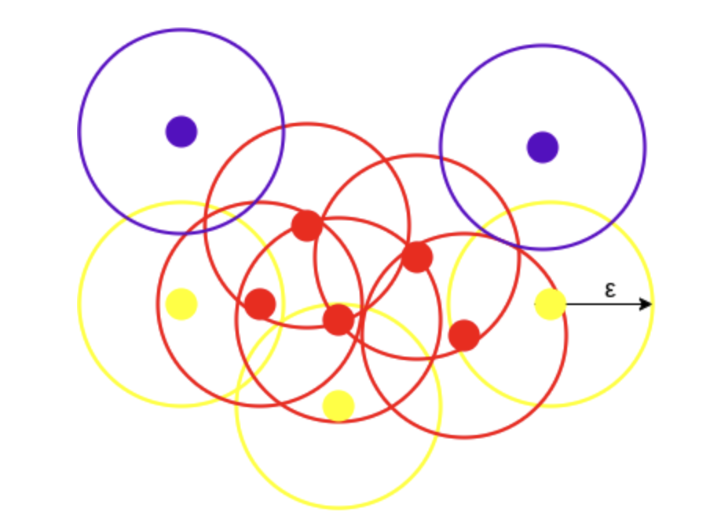

## Relationships among Points

- Reachability:
  - A point can be accessed from another point, either directly or indirectly.
- Connectivity:
  - Two points belong to the same cluster.

## Definition of a Cluster

- A cluster satisfies two properties:
  1. All points within a cluster are connected (double arrow).
  2. If point $j$ is reachable from point $i$ in the cluster, $j$ also is part of the cluster.
- Noise points are not reachable.

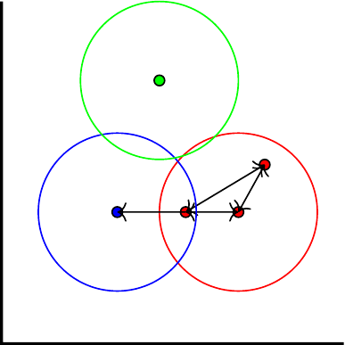

## DBSCAN Example

- Shapes
- k-Means
- DBSCAN Syntax
- DBSCAN Plot

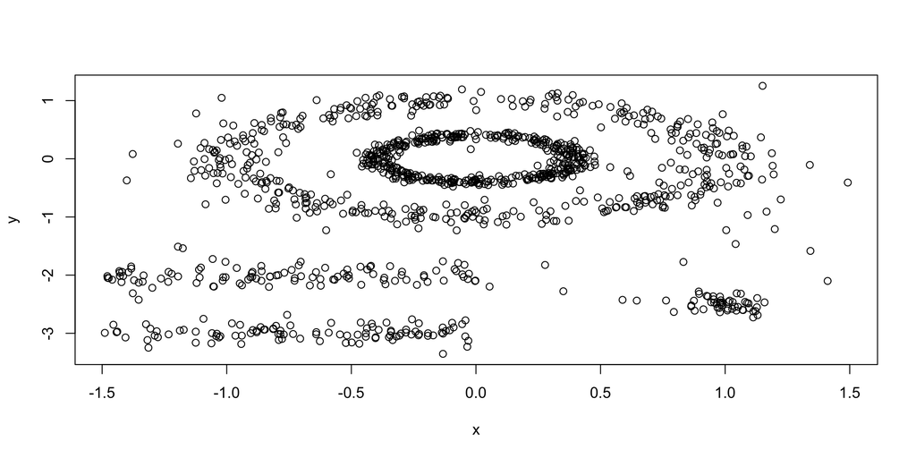

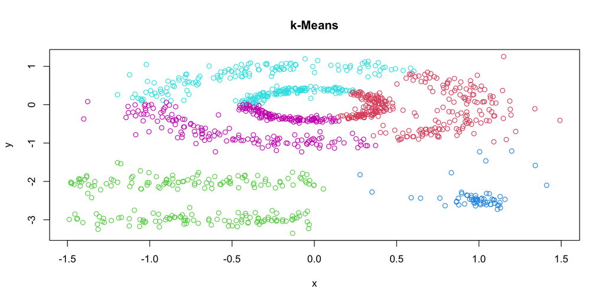

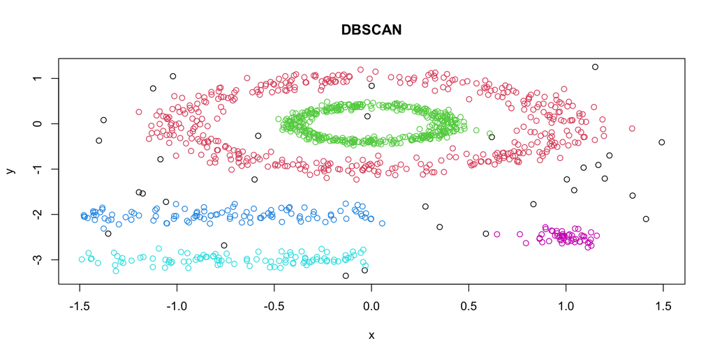

```r
library(dbscan)
dbscan_fit <- dbscan(multishapes, eps = 0.15, minPts = 5)
plot(multishapes, col = dbscan_fit$cluster+1, main = "DBSCAN")
```

# Finite Mixtures

## What Are Finite Mixtures?

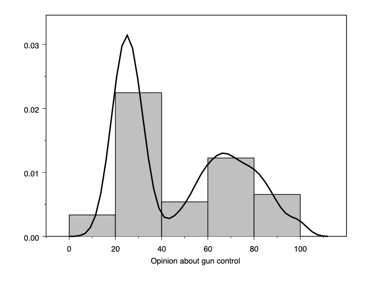

- It looks like the distribution is made up of two normal distributions.
- Put differently, there are two clusters.
- We do not know who belongs to what cluster:
  - Someone who scores 50, for instance, could belong to either cluster
- The groups/clusters are latent variables, i.e., data on group membership are missing.

## Finite Mixture Models

- A finite mixture arises when an observation could have been drawn from a finite number of groups (or components), each of which has its own distribution $p_j(y|\boldsymbol{\theta}_j)$.
- The different distributions are mixed via mixing parameters, $\pi_j$,, which capture the probability that an observations was generated by a particular component.
- The observed data are

  $$p(y) = \sum_{j=1}^k \pi_j p_j(y|\boldsymbol{\theta}_j)$$

## Mixtures Under Complete Data

If we knew the component to which unit $i$ belongs, then we could simply maximize

$$\ell = \sum_{i=1}^n \sum_{j=1}^k z_{ij} \ln \left[ \pi_j p_j(y_i|\boldsymbol{\theta}_j) \right]$$

where $z_{ij} = 1$ if $i$ belongs to component $j$ and 0 otherwise.

## A Conundrum

- We do not have any data on $z_{ij}$.
- Still, estimation is possible using the EM-algorithm (Dempster et al., 1977):
  - E(xpectation)-step: Form an expectation of $z_{ij}$, i.e., a probability.
  - M(aximization)-step: Given the expectation, maximize the other parameters.
- We iterate between the E- and M-steps.
- Convergence is guaranteed.

## Putting Finite Mixture Models to Work in Clustering

- We have a set of $P$ features, which we assume to follow the multivariate normal distribution:

  $$\boldsymbol{x}_{ij} \sim {\cal N}_P (\boldsymbol{\mu}_j,\boldsymbol{\Sigma}_j)$$
- For each instance, we assume a probability $\pi_{ij}$ that it belongs to cluster $C_j$:
  - Fuzzy membership
  - Soft $k$-means clustering

## Workflow

1. Based on an information criterion, decide on $k$ and characteristics of $\boldsymbol{\Sigma}$.
2. Cluster the data, which generates:
   1. Cluster probabilities.
   2. Cluster centroids.

## Characteristics of the Variance-Covariance Matrix

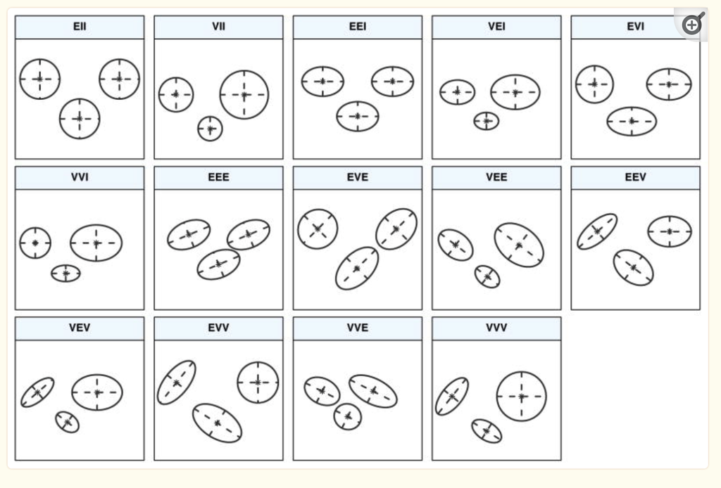

From Scrucca et al. (2016).

## Dutch Parties and Their Economic and Cultural Ideologies

- Data
- Configuration
- Solution
- Probabilities
- Plot

```r
X <- nl_df[,3:4]
row.names(X) <- nl_df$party
head(X)
```

```
     lrecon galtan
CDA    6.69   7.15
PvdA   3.62   3.08
VVD    8.15   5.00
D66    6.23   1.38
GL     2.38   0.85
SGP    7.17   9.92
```

```r
library(mclust)
set_k <- mclustBIC(X, G = 1:3)
summary(set_k)
```

```
Best BIC values:
             EII,1     VII,1       EII,2
BIC      -129.2173 -129.2173 -129.651617
BIC diff    0.0000    0.0000   -0.434268
```

```r
mix_fit <- Mclust(X, G = 2, modelNames = "EII")
mix_fit$parameters$pro
```

```
[1] 0.5896103 0.4103897
```

```r
mix_fit$parameters$mean
```

```
           [,1]     [,2]
lrecon 6.293089 3.442110
galtan 7.422101 2.732878
```

```r
round(mix_fit$z, digits = 2)
```

```
       [,1] [,2]
CDA    1.00 0.00
PvdA   0.01 0.99
VVD    0.98 0.02
D66    0.01 0.99
GL     0.00 1.00
SGP    1.00 0.00
SP     0.01 0.99
CU     0.99 0.01
PVV    1.00 0.00
PvdD   0.00 1.00
50PLUS 0.70 0.30
DENK   0.96 0.04
FvD    1.00 0.00
```

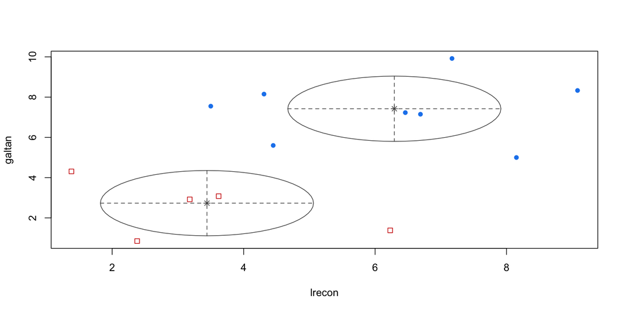

```r
plot(mix_fit, what = "classification")
```

## References

Dempster, A.P., Laird, N.M., & Rubin, D.B. (1977). Maximum Likelihood from Incomplete Data Via the *EM* Algorithm. *Journal of the Royal Statistical Society: Series B (Methodological)*, 39(1), 1–22. DOI: 10.1111/j.2517-6161.1977.tb01600.x

Ester, M., Kreigel, H.-P., Sander, J., & Xu, X. (1996). A Density-Based Algorithm for Discovering Clusters in Large Spatial Databases with Noise. In E. Simoudis, J. Han, & U. M. Fayyad (Eds.), *Proceedings of the Second International Conference on Knowledge Discovery and Data Mining (KDD-96)* (pp. 226–231). Portland, OR: AAAI Press.

Forgy, E.W. (1965). Cluster Analysis of Multivariate Data: Efficiency vs. Interpretability of Classifications. *Biometrics*, 21(3), 768–769.

Hartigan, J.A., & Wong, M.A. (1979). Algorithm AS 136: A K-Means Clustering Algorithm. *Applied Statistics*, 28(1), 100. DOI: 10.2307/2346830

Johnson, S.C. (1967). Hierarchical Clustering Schemes. *Psychometrika*, 32(3), 241–254. DOI: 10.1007/BF02289588

Kaufman, L., & Rousseeuw, P.J. (1990). *Finding Groups in Data: An Introduction to Cluster Analysis*. New York: Wiley.

Lloyd, S. (1982). Least Squares Quantization in PCM. *IEEE Transactions on Information Theory*, 28(2), 129–137. DOI: 10.1109/TIT.1982.1056489

MacQueen, J. (1967). Some Methods for Classification and Analysis of Multivariate Observations. In L. M. Le Cam & J. Neyman (Eds.), *Proceedings of the Difth Berkeley Synposium on Mathematical Statustics and Probability, Vol. 1: Statistics* (Vol. 1, pp. 281–297). Berkeley, CA: University of California Press.

Scrucca, L., Fop, M., Murphy, T.B., & Raftery, A.E. (2016). [Mclust 5: Clustering, Classification and Density Estimation Using Gaussian Finite Mixture Models](https://www.ncbi.nlm.nih.gov/pmc/articles/PMC5096736). *The R Journal*, 8(1), 289–317.

Slonim, N., Aharoni, E., & Crammer, K. (2013). Hartigan’s K-Means Versus Lloyd’s K-Means–Is It Time for a Change? In F. Rossi (Ed.), *Proceedings of the Twenty-Third international joint conference on Artificial Intelligence* (pp. 1677–1684). Beijing: AAAI Press.

Tibshirani, R., Walther, G., & Hastie, T. (2001). Estimating the Number of Clusters in a Data Set Via the Gap Statistic. *Journal of the Royal Statistical Society: Series B (Statistical Methodology)*, 63(2), 411–423. DOI: 10.1111/1467-9868.00293

Ward, J.H. (1963). Hierarchical Grouping to Optimize an Objective Function. *Journal of the American Statistical Association*, 58(301), 236–244. DOI: 10.1080/01621459.1963.10500845